# ISE Analysis

J. Beem-Miller

17 April 2020

# Introduction

This notebook contains code for reading radiocarbon data from the Ice Storm Experiment (ISE). The ISE project was initiated by Prof. Tim Fahey at Cornell University at Arnot Forest, a northern hardwood research forest maintained by Cornell University near the main campus in upstate New York. Geographic coordinates for the site are: 42.26, -76.627 (obtained from google maps; these are not coordinates for the plots themselves).

# Background

*The following notes are drawn from information supplied by T. Fahey in the file:* “ise-fahey/data/external/ise_fahey_plot-IDs_2018-12-29/README.yaml”

Fahey and collaborators simulated the effect of an ice storm on a series of plots by spraying the canopy of mature forest plots with water during mid-winter of 2016. The treatments successfully damaged the canopies of the trees. The design included two replicate plots for each of four treatments: low, mid, high and mid 2x designating different levels of ice. “2x” plots were treated in two successive years, 2016 and 2017.

The hypothesis for the experiment is that canopy damage and subsequent recovery would result in reduced C supply and increased C demand, so that trees would need to draw on older C reserves to build fine roots following the treatment.

Data analyzed in this notebook come from fine roots sampled from ingrowth cores; the codes “O” and “M” are used for organic samples from the forest floor and samples from mineral soil, respectively. Roots analyzed were sampled in the second year of the experiment (2017). Nine ingrowth cores were collected per plot, which were pooled in the lab and then split into three lab replicates for analysis. Only data from the “high”, “mid2x”, and “control” treatments were analyzed.

# Results

Plotting the raw data by treatment (“Ctl” = control; “high” = high, treated in 2016 only; “mid2x” = mid level treatment applied in both 2016 and 2017) shows a potential treatment response in the mineral horizon samples (horizon = “M”), but no clear effect in the organic horizon samples. Overall, variability is high (Fig. 1, below).

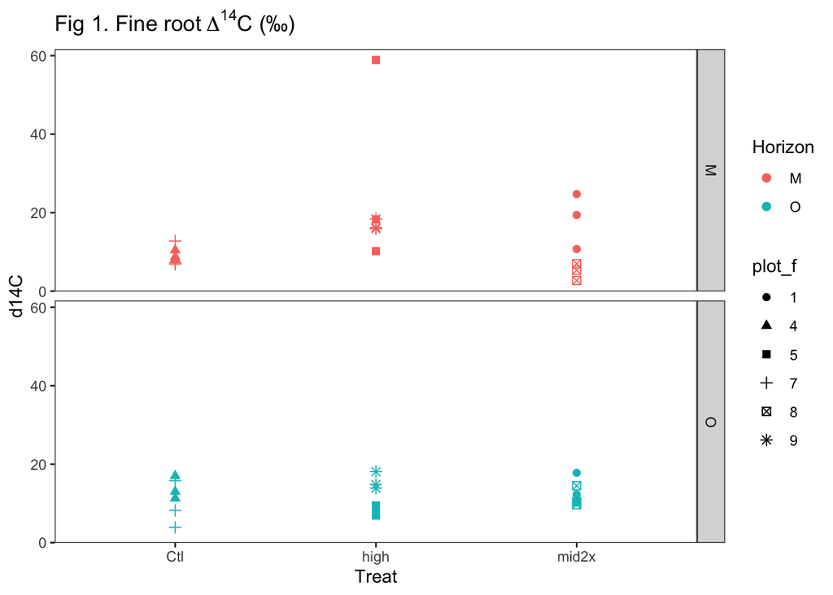

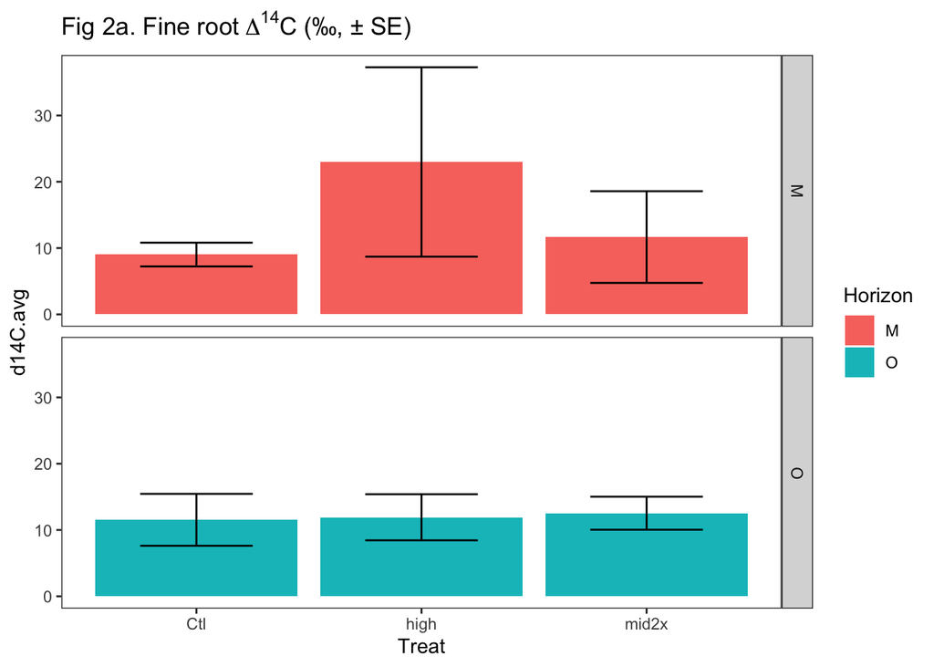

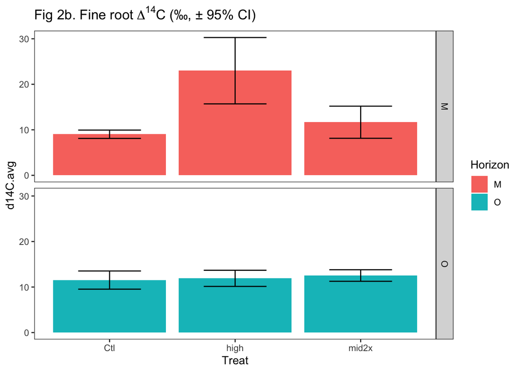

To assess the effect of individual plots, first we will create a variable representing the difference in $\Delta$<sup>14</sup>C between treatment and control samples, aggregated by plot.

Plotting the plot-level differences from the mean of the controls, by horizon, makes the differences appear more significant (Fig. 3a and 3b). However, with only three replicates per plot, perhaps these differences are not truly significant.

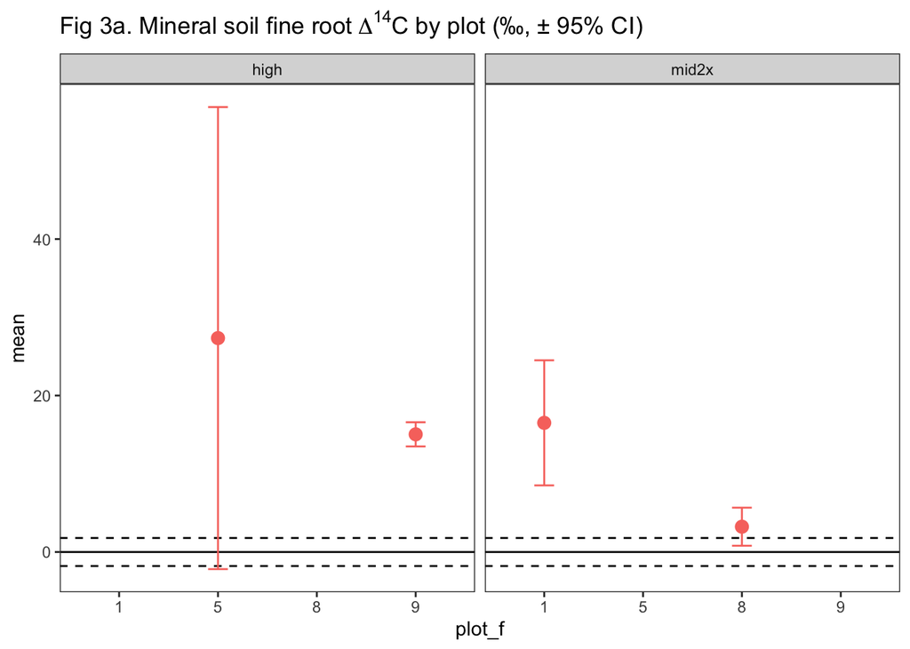

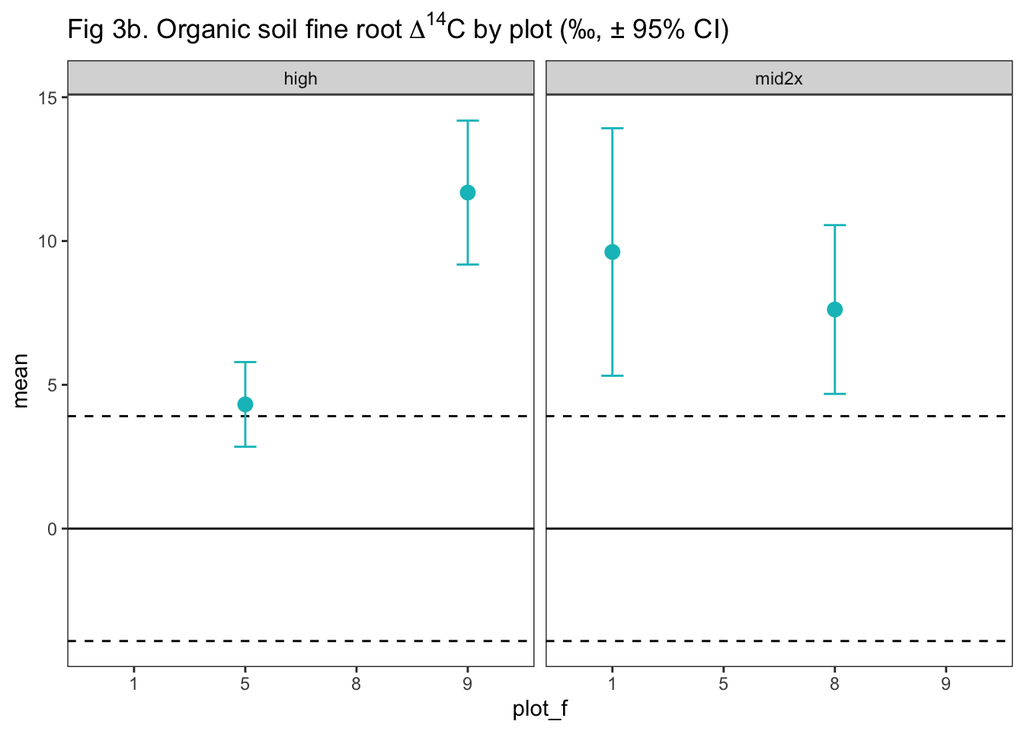

Statistically, treatment differences are not signficant at alpha = 0.05 when analyzed in a linear regression model: neither for the mineral (“M”) or organic (“O”) horizon samples.

```
##
## Call:
## lm(formula = d14C ~ Treat, data = ise[ise$Horizon == "M", ])
##
## Residuals:
##     Min      1Q  Median      3Q     Max
## -12.783  -5.912  -1.981   0.997  35.917
##
## Coefficients:
##             Estimate Std. Error t value Pr(>|t|)
## (Intercept)    9.023      4.703   1.918   0.0743 .
## Treathigh     13.961      6.652   2.099   0.0532 .
## Treatmid2x     2.640      6.652   0.397   0.6970
## ---
## Signif. codes:  0 '***' 0.001 '**' 0.01 '*' 0.05 '.' 0.1 ' ' 1
##
## Residual standard error: 11.52 on 15 degrees of freedom
## Multiple R-squared:  0.249,  Adjusted R-squared:  0.1488
## F-statistic: 2.486 on 2 and 15 DF,  p-value: 0.1168
```

```
##
## Call:
## lm(formula = d14C ~ Treat, data = ise[ise$Horizon == "O", ])
##
## Residuals:
##     Min      1Q  Median      3Q     Max
## -7.6333 -2.7292 -0.2333  2.6583  6.1833
##
## Coefficients:
##             Estimate Std. Error t value Pr(>|t|)
## (Intercept)  11.5333     1.7082   6.752  6.5e-06 ***
## Treathigh     0.3833     2.4158   0.159    0.876
## Treatmid2x    1.0000     2.4158   0.414    0.685
## ---
## Signif. codes:  0 '***' 0.001 '**' 0.01 '*' 0.05 '.' 0.1 ' ' 1
##
## Residual standard error: 4.184 on 15 degrees of freedom
## Multiple R-squared:  0.0115, Adjusted R-squared:  -0.1203
## F-statistic: 0.08723 on 2 and 15 DF,  p-value: 0.9169
```

Contrasts are also not significant:

```
##   Tukey multiple comparisons of means
##     95% family-wise confidence level
##
## Fit: aov(formula = d14C ~ Treat, data = ise[ise$Horizon == "M", ])
##
## $Treat
##                  diff       lwr       upr     p adj
## high-Ctl    13.960520  -3.31703 31.238071 0.1236913
## mid2x-Ctl    2.640396 -14.63715 19.917947 0.9172805
## mid2x-high -11.320124 -28.59767  5.957426 0.2368351
```

```
##   Tukey multiple comparisons of means
##     95% family-wise confidence level
##
## Fit: aov(formula = d14C ~ Treat, data = ise[ise$Horizon == "O", ])
##
## $Treat
##                 diff       lwr      upr     p adj
## high-Ctl   0.3833333 -5.891527 6.658194 0.9862272
## mid2x-Ctl  1.0000000 -5.274861 7.274861 0.9104244
## mid2x-high 0.6166667 -5.658194 6.891527 0.9648001
```

A mixed model approach with plot considered as a random factor shows the same results: while there is no signficant treatment effect for organic horizon samples, treatment effects are marginally signficant (Pr(>Chisq)) for mineral samples, which we know is heavily influenced by the data from rep 1 of the “high” damage treatment (sample ID = high_M_1).

```r
## Mixed model, considering effect of plot
# Min samples
ise.mm.m <- lmer(d14C ~ Treat + (1 | plot_f), REML = FALSE, data = ise[ise$Horizon == "M", ])
```

```
## boundary (singular) fit: see ?isSingular
```

```r
summary(ise.mm.m)
```

```
## Linear mixed model fit by maximum likelihood  ['lmerMod']
## Formula: d14C ~ Treat + (1 | plot_f)
##    Data: ise[ise$Horizon == "M", ]
##
##      AIC      BIC   logLik deviance df.resid
##    145.8    150.2    -67.9    135.8       13
##
## Scaled residuals:
##     Min      1Q  Median      3Q     Max
## -1.2155 -0.5622 -0.1884  0.0948  3.4150
##
## Random effects:
##  Groups   Name        Variance Std.Dev.
##  plot_f   (Intercept)   0.0     0.00
##  Residual             110.6    10.52
## Number of obs: 18, groups:  plot_f, 6
##
## Fixed effects:
##             Estimate Std. Error t value
## (Intercept)    9.023      4.294   2.101
## Treathigh     13.961      6.072   2.299
## Treatmid2x     2.640      6.072   0.435
##
## Correlation of Fixed Effects:
##            (Intr) Trthgh
## Treathigh  -0.707
## Treatmid2x -0.707  0.500
## convergence code: 0
## boundary (singular) fit: see ?isSingular
```

```r
# compare unrestricted to restricted fit, i.e. w/o effect of Treat
ise.mm.m.0 <- lmer(d14C ~ (1 | plot_f), REML = F, ise[ise$Horizon == "M", ])
anova(ise.mm.m.0, ise.mm.m)
```

|  | Df | AIC | BIC | logLik | deviance | Chisq | Chi Df | Pr(>Chisq) |
| --- | --- | --- | --- | --- | --- | --- | --- | --- |
| ise.mm.m.0 | 3 | 146.5608 | 149.2319 | -70.28038 | 140.5608 | NA | NA | NA |
| ise.mm.m | 5 | 145.7903 | 150.2422 | -67.89517 | 135.7903 | 4.770413 | 2 | 0.09206997 |

```r
# Org samples:
ise.mm.o <- lmer(d14C ~ Treat + (1 | plot_f), data = ise[ise$Horizon == "O", ], REML = FALSE)
summary(ise.mm.o)
```

```
## Linear mixed model fit by maximum likelihood  ['lmerMod']
## Formula: d14C ~ Treat + (1 | plot_f)
##    Data: ise[ise$Horizon == "O", ]
##
##      AIC      BIC   logLik deviance df.resid
##    108.8    113.3    -49.4     98.8       13
##
## Scaled residuals:
##     Min      1Q  Median      3Q     Max
## -1.9493 -0.6794 -0.2339  0.6124  1.4707
##
## Random effects:
##  Groups   Name        Variance Std.Dev.
##  plot_f   (Intercept)  2.482   1.576
##  Residual             12.107   3.480
## Number of obs: 18, groups:  plot_f, 6
##
## Fixed effects:
##             Estimate Std. Error t value
## (Intercept)  11.5333     1.8053   6.389
## Treathigh     0.3833     2.5531   0.150
## Treatmid2x    1.0000     2.5531   0.392
##
## Correlation of Fixed Effects:
##            (Intr) Trthgh
## Treathigh  -0.707
## Treatmid2x -0.707  0.500
```

```r
# compare unrestricted to restricted fit, i.e. w/o effect of Treat
ise.mm.o.0 <- lmer(d14C ~ (1 | plot_f), REML = F, ise[ise$Horizon == "O", ])
anova(ise.mm.o.0, ise.mm.o)
```

|  | Df | AIC | BIC | logLik | deviance | Chisq | Chi Df | Pr(>Chisq) |
| --- | --- | --- | --- | --- | --- | --- | --- | --- |
| ise.mm.o.0 | 3 | 105.0009 | 107.6720 | -49.50046 | 99.00092 | NA | NA | NA |
| ise.mm.o | 5 | 108.8467 | 113.2986 | -49.42336 | 98.84671 | 0.1542013 | 2 | 0.9257967 |

```r
# Wald test for significance of Treatment in mixed models
Anova(ise.mm.m) # marginal signficance
```

|  | Chisq | Df | Pr(>Chisq) |
| --- | --- | --- | --- |
| Treat | 5.967025 | 2 | 0.05061473 |

```r
Anova(ise.mm.o) # ns
```

|  | Chisq | Df | Pr(>Chisq) |
| --- | --- | --- | --- |
| Treat | 0.1561998 | 2 | 0.924872 |

# Conclusion

Overall, there is no evidence for treatment effects in the organic horizon samples, but some evidence of enrichment in mineral soil samples in response to treatment—especially the “high” damage treatment. The observed effect is in line with the hypothesis, i.e. mobilization of older (more enriched) carbon reserves in response to damage.